# Practical Machine Learning Project

Sarah Lott

2023-03-09

NOTE: all code can be found in chapter “Code”

## Task

Predict the manner in which the participants of a study did barbell lifts based on a set of observations from different measurement devices.

## Data exploration

The training data set contains data of 6 participants from accelerometers on the belt, forearm, arm, and dumbell. The participants had to do barbell lifts in 5 different incorrect ways, which are specified in the variable “classe” (A,B,C,D,E).

## Cleaning the data

The given test data set has several columns with no information (NA), these are dropped. Then the same columns are dropped from the training data set. Within the training data set all empty values or values equal “#DIV/0!” are replaced by NA. Afterwards only the feature values are selected and columns are converted to correct data types. The final step is to divide the data into a training (70%) and a validation (30%) data set. The training and validation data sets have now 53 columns (52 features and the classification variable “classe”).

## Models

In the following two models are applied to the training data set and the accuracy on the validation data set is calculated.

### Classification Tree

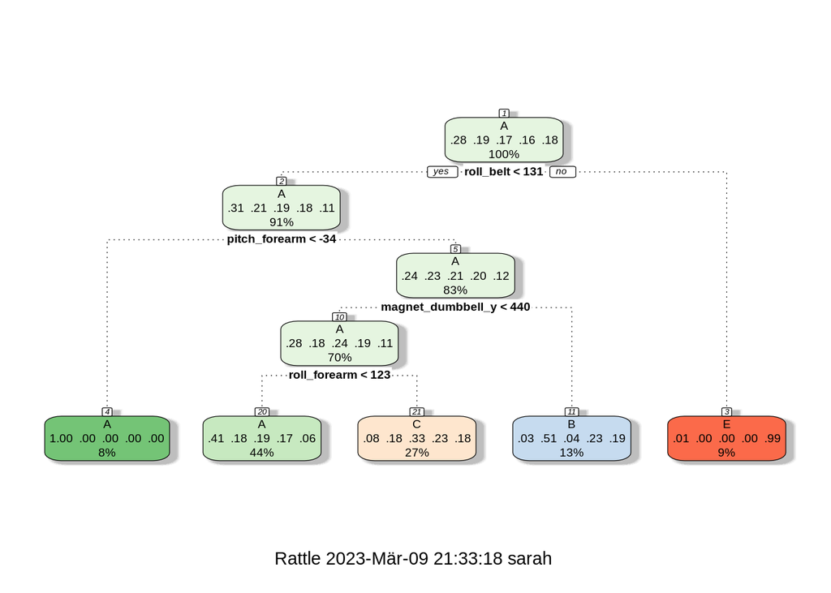

```
##           Reference
## Prediction    A    B    C    D    E
##          A 1520  483  457  439  160
##          B   24  374   35  167  150
##          C  125  282  534  358  303
##          D    0    0    0    0    0
##          E    5    0    0    0  469
```

```
##       Accuracy          Kappa  AccuracyLower  AccuracyUpper   AccuracyNull
##   4.922685e-01   3.364808e-01   4.794170e-01   5.051276e-01   2.844520e-01
## AccuracyPValue  McnemarPValue
##  2.670931e-247            NaN
```

### Random Forest

```
##           Reference
## Prediction    A    B    C    D    E
##          A 1674    5    0    0    0
##          B    0 1128    8    0    0
##          C    0    6 1018   10    0
##          D    0    0    0  952    4
##          E    0    0    0    2 1078
```

```
##       Accuracy          Kappa  AccuracyLower  AccuracyUpper   AccuracyNull
##      0.9940527      0.9924765      0.9917383      0.9958541      0.2844520
## AccuracyPValue  McnemarPValue
##      0.0000000            NaN
```

### Comparison of models

The accuracy of the classification tree is low (0.492) and as can be seen in the plot no tree results in classe = D. The random forest model performs much better with a high accuracy (0.994).

## Prediction on test data set

Because of the better performance, the random forest model is chosen to be applied to the test data set.

```r
pred_rf <- predict(mod_rf, df_test)
pred_rf
```

```
##  1  2  3  4  5  6  7  8  9 10 11 12 13 14 15 16 17 18 19 20
##  B  A  B  A  A  E  D  B  A  A  B  C  B  A  E  E  A  B  B  B
## Levels: A B C D E
```

## Code

```r
# select relevant columns
# remove all columns that have no data in the validation data set
df_test <- df_test[,colSums(is.na(df_test))<nrow(df_test)]
# get common column names
dfList <- list(df, df_test)
dfColList <- lapply(dfList,names)
commonCols <- Reduce(intersect,dfColList)
# keep only column names that are also in the validation data set
df <- subset(df, select = c(append(commonCols, "classe")))
# clean data
df[df == "#DIV/0!"] <- NA
df[df == ""] <- NA
# extract features
df_features <- subset(df, select = -c(X,
                                      user_name,
                                      raw_timestamp_part_1,
                                      raw_timestamp_part_2,
                                      cvtd_timestamp,
                                      new_window,
                                      num_window))
# convert variable classe to factor
df_features$classe <- factor(df_features$classe)
# convert to numeric
df_features <- df_features %>%
    mutate_if(is.character, as.numeric)
# split into training and test set
inTrain <- createDataPartition(y = df_features$classe, p = .7, list = FALSE)
df_myTraining <- df_features[inTrain,]
df_myValidation <- df_features[-inTrain,]
```

```r
mod_classification <- train(classe ~ ., method = "rpart", data = df_myTraining)
#fancyRpartPlot(mod_classification$finalModel)
pred_classification <- predict(mod_classification, df_myValidation)
confMatrix_classification <- confusionMatrix(pred_classification, df_myValidation$classe)
accuracy_classification <- confusionMatrix(pred_classification, df_myValidation$classe)$overall["Accuracy"]
#confMatrix_classification$table
#confMatrix_classification$overall
```

```r
mod_rf <- randomForest(classe ~ ., data = df_myTraining)
pred_rf <- predict(mod_rf, df_myValidation)
confMatrix_rf <- confusionMatrix(pred_rf, df_myValidation$classe)
accuracy_rf <- confusionMatrix(pred_rf, df_myValidation$classe)$overall["Accuracy"]
#confMatrix_rf$table
#confMatrix_rf$overall
```